# Project_Bank_Churn_Prediction

## Project_Bank_Churn_Prediction

## Background and Context

Businesses like banks that provide service have to worry about the problem of 'Churn' i.e. customers leaving and joining another service provider. It is important to understand which aspects of the service influence a customer's decision in this regard. Management can concentrate efforts on the improvement of service, keeping in mind these priorities.

## Objective

Given a Bank customer, build a neural network-based classifier that can determine whether they will leave or not in the next 6 months.

## Data Description

The case study is from an open-source dataset from Kaggle. The dataset contains 10,000 sample points with 14 distinct features such as CustomerId, CreditScore, Geography, Gender, Age, Tenure, Balance, etc.

## Data Dictionary

- RowNumber: Row number.
- CustomerId: Unique identification key for different customers.
- Surname: Surname of the customer
- Credit Score: A credit score is a measure of an individual's ability to pay back the borrowed amount. It is the numerical representation of their creditworthiness. A credit score is a 3-digit number that falls in the range of 300-900, 900 being the highest.
- Geography: The country to which the customer belongs.
- Gender: The gender of the customer.
- Age: Age of the customer.
- Tenure: The period of time a customer has been associated with the bank.
- Balance: The account balance (the amount of money deposited in the bank account) of the customer.
- NumOfProducts: How many accounts, bank account affiliated products the person has.
- HasCrCard: Does the customer have a credit card through the bank?
- IsActiveMember: Subjective, but for the concept
- EstimatedSalary: Estimated salary of the customer.
- Exited: Did they leave the bank after all?

## Index

- Import Libraries
- Reading Dataset and Feature Elimination
  - Overview of the dataset
  - Feature Elimination
- Exploratory Data Analysis
- Illustrate the insights based on EDA
- Data Pre-processing
  - Outlier detection
  - Split data into dependent and Independent variable
  - One hot Encoding
  - Split data into train , validation and test set
  - Data Scaling
- Model evaluation criterion
- Model building
- Model Performance Improvement
- Model Performance Evaluation
- Conclusion and key takeaways

## Import Libraries

```python
#importing tensorflow
import tensorflow as tf
print(tf.__version__)
```

```
2.2.1
```

```python
import pandas as pd
import numpy as np
from sklearn.model_selection import train_test_split
from sklearn import preprocessing
from sklearn.preprocessing import StandardScaler


#Libraries for Neural Network model creation
from tensorflow.keras.models import Sequential
from tensorflow.keras.layers import Dense, Dropout
from tensorflow.keras import optimizers
from tensorflow.keras.optimizers import Adam
from tensorflow.keras.metrics import Recall as recall


#Libraries for graphs
import matplotlib.pyplot as plt
import seaborn as sns


# Libraries for classification model evaluation
from sklearn.metrics import confusion_matrix, recall_score, precision_score, f1_score, roc_curve,roc_auc_score,accuracy_score
from sklearn.linear_model import LogisticRegression
from sklearn.metrics import precision_recall_curve
from sklearn.metrics import auc
```

## Reading Dataset and Feature Elimination

```python
#reading dataset
data = pd.read_csv("bank.csv")
```

### Overview of the dataset

```python
# displays the head of the pandas df
data.head()
```

|  | RowNumber | CustomerId | Surname | CreditScore | Geography | Gender | Age | Tenure | Balance | NumOfProducts | HasCrCard | IsActiveMember | EstimatedSalary | Exited |
| --- | --- | --- | --- | --- | --- | --- | --- | --- | --- | --- | --- | --- | --- | --- |
| 0 | 1 | 15634602 | Hargrave | 619 | France | Female | 42 | 2 | 0.00 | 1 | 1 | 1 | 101348.88 | 1 |
| 1 | 2 | 15647311 | Hill | 608 | Spain | Female | 41 | 1 | 83807.86 | 1 | 0 | 1 | 112542.58 | 0 |
| 2 | 3 | 15619304 | Onio | 502 | France | Female | 42 | 8 | 159660.80 | 3 | 1 | 0 | 113931.57 | 1 |
| 3 | 4 | 15701354 | Boni | 699 | France | Female | 39 | 1 | 0.00 | 2 | 0 | 0 | 93826.63 | 0 |
| 4 | 5 | 15737888 | Mitchell | 850 | Spain | Female | 43 | 2 | 125510.82 | 1 | 1 | 1 | 79084.10 | 0 |

```python
# display pandas dataframe info
data.info()
```

```
<class 'pandas.core.frame.DataFrame'>
RangeIndex: 10000 entries, 0 to 9999
Data columns (total 14 columns):
 #   Column           Non-Null Count  Dtype
---  ------           --------------  -----
 0   RowNumber        10000 non-null  int64
 1   CustomerId       10000 non-null  int64
 2   Surname          10000 non-null  object
 3   CreditScore      10000 non-null  int64
 4   Geography        10000 non-null  object
 5   Gender           10000 non-null  object
 6   Age              10000 non-null  int64
 7   Tenure           10000 non-null  int64
 8   Balance          10000 non-null  float64
 9   NumOfProducts    10000 non-null  int64
 10  HasCrCard        10000 non-null  int64
 11  IsActiveMember   10000 non-null  int64
 12  EstimatedSalary  10000 non-null  float64
 13  Exited           10000 non-null  int64
dtypes: float64(2), int64(9), object(3)
memory usage: 1.1+ MB
```

**Insights**

There are no null values in any of the columns.  
As per the problem statement, Exited is dependent column.  
There are 2 columns of float type, 9 of integer type and 3 columns of string type.

```python
#diplay shape of the data
data.shape
```

```
(10000, 14)
```

- There are 10000 instances and 14 attributes including Exited column( Dependent column).

```python
# display statistical summary
data.describe()
```

|  | RowNumber | CustomerId | CreditScore | Age | Tenure | Balance | NumOfProducts | HasCrCard | IsActiveMember | EstimatedSalary | Exited |
| --- | --- | --- | --- | --- | --- | --- | --- | --- | --- | --- | --- |
| count | 10000.00000 | 1.000000e+04 | 10000.000000 | 10000.000000 | 10000.000000 | 10000.000000 | 10000.000000 | 10000.00000 | 10000.000000 | 10000.000000 | 10000.000000 |
| mean | 5000.50000 | 1.569094e+07 | 650.528800 | 38.921800 | 5.012800 | 76485.889288 | 1.530200 | 0.70550 | 0.515100 | 100090.239881 | 0.203700 |
| std | 2886.89568 | 7.193619e+04 | 96.653299 | 10.487806 | 2.892174 | 62397.405202 | 0.581654 | 0.45584 | 0.499797 | 57510.492818 | 0.402769 |
| min | 1.00000 | 1.556570e+07 | 350.000000 | 18.000000 | 0.000000 | 0.000000 | 1.000000 | 0.00000 | 0.000000 | 11.580000 | 0.000000 |
| 25% | 2500.75000 | 1.562853e+07 | 584.000000 | 32.000000 | 3.000000 | 0.000000 | 1.000000 | 0.00000 | 0.000000 | 51002.110000 | 0.000000 |
| 50% | 5000.50000 | 1.569074e+07 | 652.000000 | 37.000000 | 5.000000 | 97198.540000 | 1.000000 | 1.00000 | 1.000000 | 100193.915000 | 0.000000 |
| 75% | 7500.25000 | 1.575323e+07 | 718.000000 | 44.000000 | 7.000000 | 127644.240000 | 2.000000 | 1.00000 | 1.000000 | 149388.247500 | 0.000000 |
| max | 10000.00000 | 1.581569e+07 | 850.000000 | 92.000000 | 10.000000 | 250898.090000 | 4.000000 | 1.00000 | 1.000000 | 199992.480000 | 1.000000 |

**Insights**

- Credit score max is 850 and min is 350. mean is 650. looks like data is properly distrubuted.
- Tenure: minimum value is 0, Description for tenure column is given as period of time. Assuming that it is in years, 0 value can be assumed as less than 1 year. or it might be an error.
- Balance: Minimum value is 0 which is not impossible. few accounts can have 0 balance. what looks abnormal is even 25 percentile is also 0. many accounts have zero balance.
- There are max of 4 products in the given dataset.

```python
# take backup of original data
data_backup = data.copy()
```

```python
# Find the unique values of object datatype columns

for col in data.columns:
    if(data[col].dtypes=='object'):
        print(col+':')
        print(data[col].unique())
```

```
Surname:
['Hargrave' 'Hill' 'Onio' ... 'Kashiwagi' 'Aldridge' 'Burbidge']
Geography:
['France' 'Spain' 'Germany']
Gender:
['Female' 'Male']
```

**Insights**

- There are 3 entries in Geography['France' 'Spain' 'Germany']

```python
# Find the number of each unique values of object datatype columns

for col in data.columns:
   if(data[col].dtypes=='object'):
       print('-----------------------')
       print(col+':')
       print(data[col].value_counts())
       print('------------------------')
```

```
-----------------------
Surname:
Smith       32
Scott       29
Martin      29
Walker      28
Brown       26
            ..
Donoghue     1
Vale         1
Lockyer      1
Mullah       1
Persse       1
Name: Surname, Length: 2932, dtype: int64
------------------------
-----------------------
Geography:
France     5014
Germany    2509
Spain      2477
Name: Geography, dtype: int64
------------------------
-----------------------
Gender:
Male      5457
Female    4543
Name: Gender, dtype: int64
------------------------
```

### Feature Elimination

```python
# check for duplicate columns in RowNumber, CustomerId

print('Unique values in CustomerId column',data['CustomerId'].nunique())
print('Unique values in RowNumber column',data['RowNumber'].nunique())

# Number of Unique values are same as number of rows in the given set. so there are no duplicates in this columns
```

```
Unique values in CustomerId column 10000
Unique values in RowNumber column 10000
```

RowNumber, CustomerId, Surname can be removed from the dataset for the model prediction.

RowNumber, CustomerId are unique values which have no affect on dependent variable.  
Also Surname (though it is not unique) this does not have any affect on dependent varialbe.

```python
data = data.drop(['RowNumber', 'CustomerId', 'Surname'], axis =1)
```

```python
data.shape
```

```
(10000, 11)
```

```python
data.info()
```

```
<class 'pandas.core.frame.DataFrame'>
RangeIndex: 10000 entries, 0 to 9999
Data columns (total 11 columns):
 #   Column           Non-Null Count  Dtype
---  ------           --------------  -----
 0   CreditScore      10000 non-null  int64
 1   Geography        10000 non-null  object
 2   Gender           10000 non-null  object
 3   Age              10000 non-null  int64
 4   Tenure           10000 non-null  int64
 5   Balance          10000 non-null  float64
 6   NumOfProducts    10000 non-null  int64
 7   HasCrCard        10000 non-null  int64
 8   IsActiveMember   10000 non-null  int64
 9   EstimatedSalary  10000 non-null  float64
 10  Exited           10000 non-null  int64
dtypes: float64(2), int64(7), object(2)
memory usage: 859.5+ KB
```

## EDA

```python
#checking the percentage of each class in the dataset
(data.Exited.value_counts())/(data.Exited.count())
```

```
0    0.7963
1    0.2037
Name: Exited, dtype: float64
```

- The data set is unbalanced. only 20% of entire data exited the services.

```python
### Function to plot stacked bar charts for categorical columns
def stacked_plot(x):
    sns.set(palette="nipy_spectral")
    tab1 = pd.crosstab(x, data["Exited"], margins=True)
    print(tab1)
    print("-" * 120)
    tab = pd.crosstab(x, data["Exited"], normalize="index")
    tab.plot(kind="bar", stacked=True, figsize=(10, 5))
    plt.legend(loc="lower left", frameon=False)
    plt.legend(loc="upper left", bbox_to_anchor=(1, 1))
    plt.show()
```

```
Exited     0     1    All
Gender
Female  3404  1139   4543
Male    4559   898   5457
All     7963  2037  10000
------------------------------------------------------------------------------------------------------------------------
```

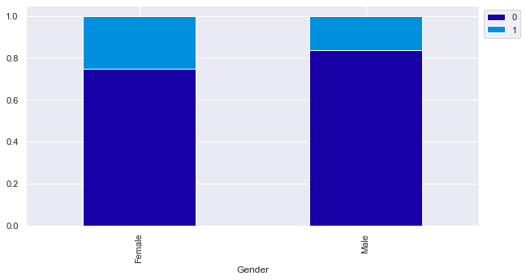

```python
stacked_plot(data['Gender'])
```

**Insights**

- Females are the one who exited more .

```
Exited        0     1    All
HasCrCard
0          2332   613   2945
1          5631  1424   7055
All        7963  2037  10000
------------------------------------------------------------------------------------------------------------------------
```

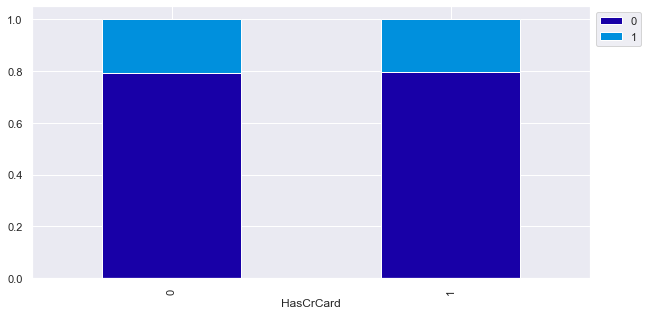

```python
stacked_plot(data['HasCrCard'])
```

- Customer having or not having credit card did not impact the churn rate.

```
Exited        0     1    All
Geography
France     4204   810   5014
Germany    1695   814   2509
Spain      2064   413   2477
All        7963  2037  10000
------------------------------------------------------------------------------------------------------------------------
```

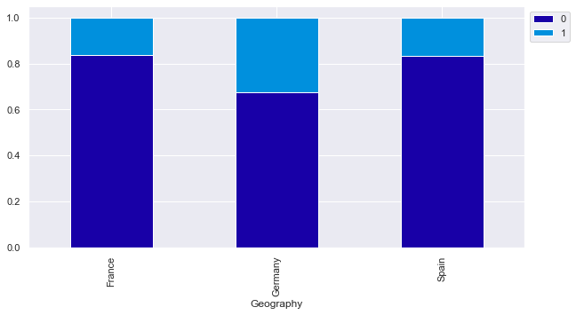

```python
stacked_plot(data['Geography'])
```

**Insights**

- Germany has more customers who exited bank services than France and Spain.
- France and Spain show similar churn rate.

```
Exited             0     1    All
IsActiveMember
0               3547  1302   4849
1               4416   735   5151
All             7963  2037  10000
------------------------------------------------------------------------------------------------------------------------
```

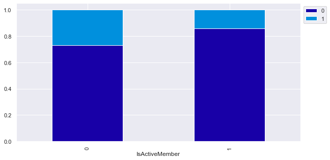

```python
stacked_plot(data['IsActiveMember'])
```

**Insights**

- Inactive members exited more.

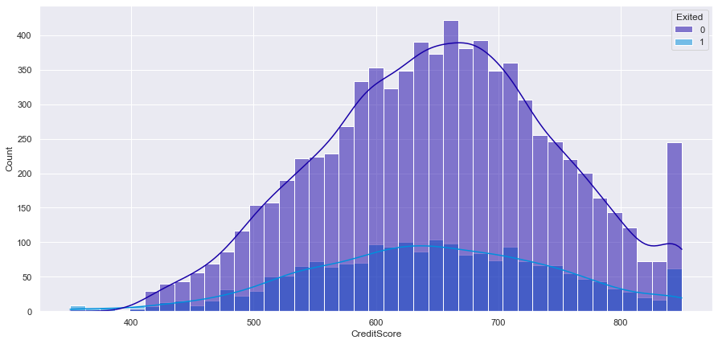

```python
# Display hist plot for data['CreditScore'] and data['Exited'] showed as hue variation
plt.figure(figsize=(15,7))
sns.histplot(data, x= data['CreditScore'],hue=data['Exited'],kde=1)
```

**Insights**

- Customers with mid credit score(600- 700) range exited more.
- Also customer with high score also exited. This is shown by some unusual raise at the end.

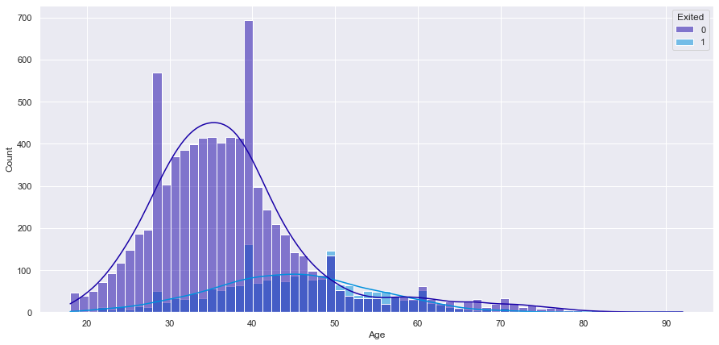

```python
# Display hist plot for data['Age'] and data['Exited'] showed as hue variation
plt.figure(figsize=(15,7))
sns.histplot(data, x= data['Age'],hue=data['Exited'],kde=1)
```

**Insights**

The are more customers exited between the age range of 40 -50

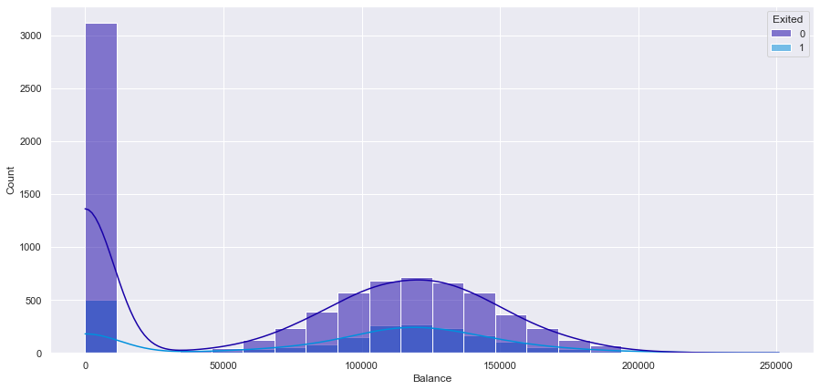

```python
# Display hist plot for data['Balance'] and data['Exited'] showed as hue variation
plt.figure(figsize=(15,7))
sns.histplot(data, x= data['Balance'],hue=data['Exited'],kde=1)
```

**Insights**

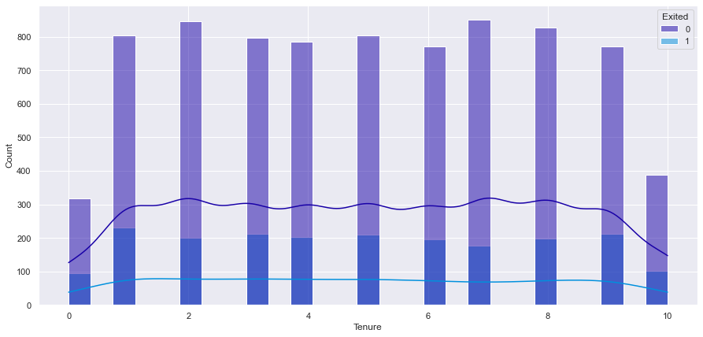

```python
# Display hist plot for data['Tenure'] and data['Exited'] showed as hue variation
plt.figure(figsize=(15,7))
sns.histplot(data, x= data['Tenure'],hue=data['Exited'],kde=1)
```

**Insights**

- Customers with zero and ten tenure have exited less.
- All other time periods of tenure have similar churn numbers.

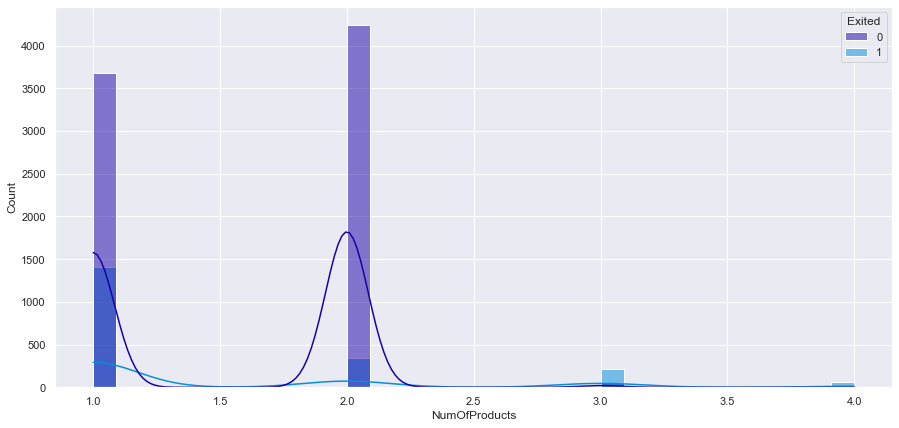

```python
# Display hist plot for data['NumOfProducts'] and data['Exited'] showed as hue variation
plt.figure(figsize=(15,7))
sns.histplot(data, x= data['NumOfProducts'],hue=data['Exited'],kde=1)
```

**Insights**

- Customers with one products showed major exit rate.

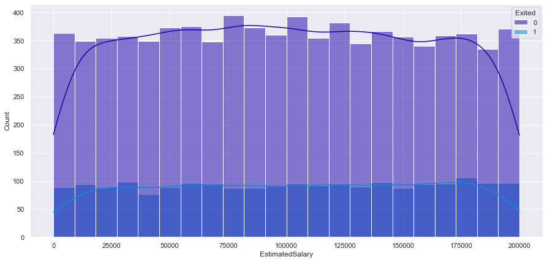

```python
# Display hist plot for data['NumOfProducts'] and data['Exited'] showed as hue variation
plt.figure(figsize=(15,7))
sns.histplot(data, x= data['EstimatedSalary'],hue=data['Exited'],kde=1)
```

**Insights**

- There is even distribution of customers among all the Salary ranges.

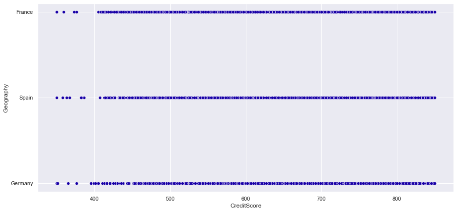

```python
# Display scatter plot for data['CreditScore'] and data['Geography'] showed as hue variation
plt.figure(figsize=(15,7))
sns.scatterplot(x= data['CreditScore'],y=data['Geography'])
```

**Insights**

- There is similar distribution of credit score in all the given geographicla areas.

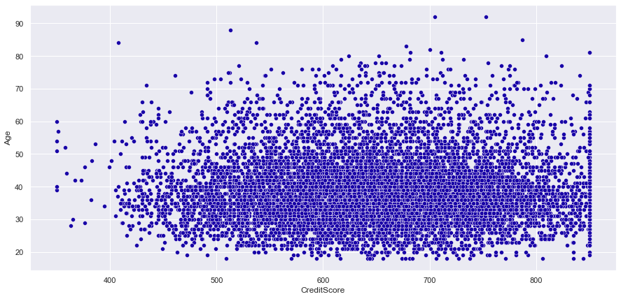

```python
# Display scatter plot for data['CreditScore'] and data['Age'] showed as hue variation
plt.figure(figsize=(15,7))
sns.scatterplot(x= data['CreditScore'],y=data['Age'])
```

**Insights**

- cannot find any specific pattern between Age and CreditScore.
- I can see one specifc line at the end which shows points span accross all age groups having high credit score. but this might be because of credit score cutoff(850) in the given data.

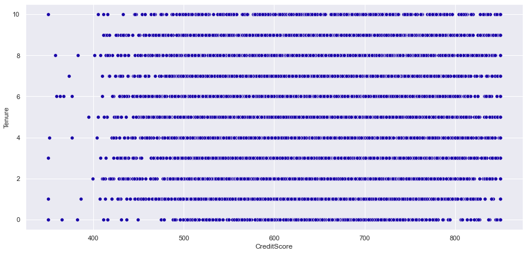

```python
# Display scatter plot for data['CreditScore'] and data['Age'] showed as hue variation
plt.figure(figsize=(15,7))
sns.scatterplot(x= data['CreditScore'],y=data['Tenure'])
```

**Insights**

- There are few customers with less credit score in all tenure time periods.
- Few customers with 0 tenure have high credit score. Bank might have given this with previous customer history.

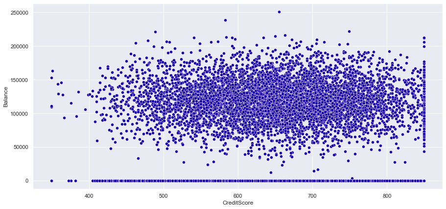

```python
# Display scatter plot for data['CreditScore'] and data['Balance'] showed as hue variation
plt.figure(figsize=(15,7))
sns.scatterplot(x= data['CreditScore'],y=data['Balance'])
```

**Insights**

- There is no proper pattern between Balance and Credit Score.
- what looks abnormal is few customers with 0 balance are given high credit score.

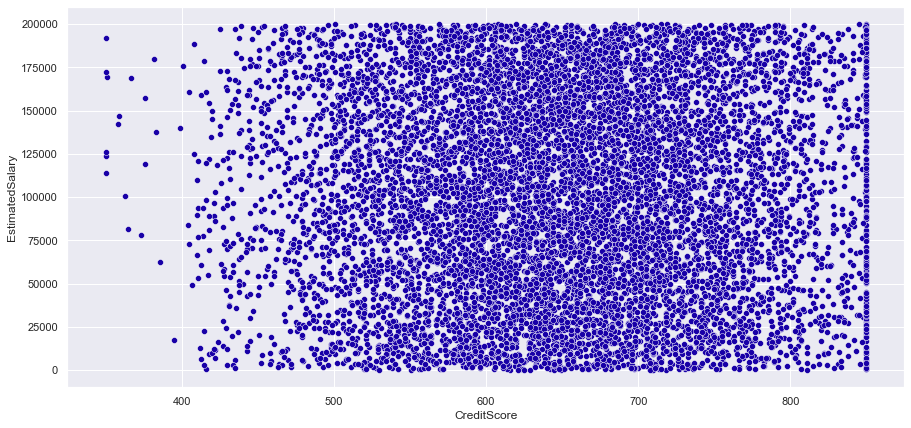

```python
# Display scatter plot for data['CreditScore'] and data['EstimatedSalary'] showed as hue variation
plt.figure(figsize=(15,7))
sns.scatterplot(x= data['CreditScore'],y=data['EstimatedSalary'])
```

**Insights**

- I see noproper pattern between EstimatedSalary and CreditScore
- Only ther very few cutomers with credit score<400

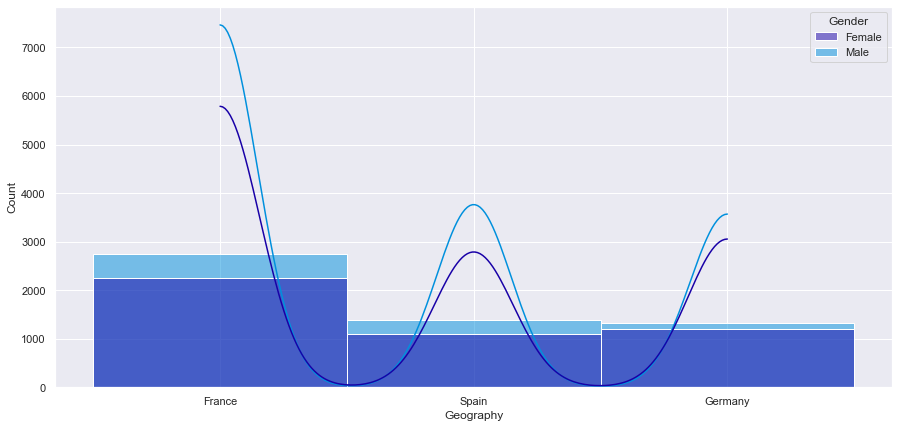

```python
# Display hist plot for data['Geography'] and data['Gender'] showed as hue variation
plt.figure(figsize=(15,7))
sns.histplot(data, x= data['Geography'],hue=data['Gender'],kde=1)
```

**Insights**

- In all the geographies, males are more.
- In Germany the males and Females are appox equal .

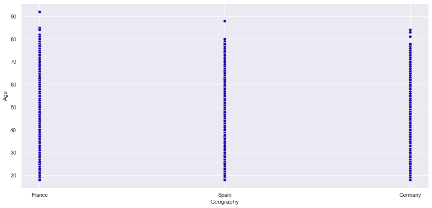

```python
# Display scatter plot for data['Geography'] and data['Age'] showed as hue variation
plt.figure(figsize=(15,7))
sns.scatterplot(x= data['Geography'],y=data['Age'])
```

**Insights**

- there is similar distribution of age in all the grographies.
- with one exception where France is have some aged customers with max age as 90.

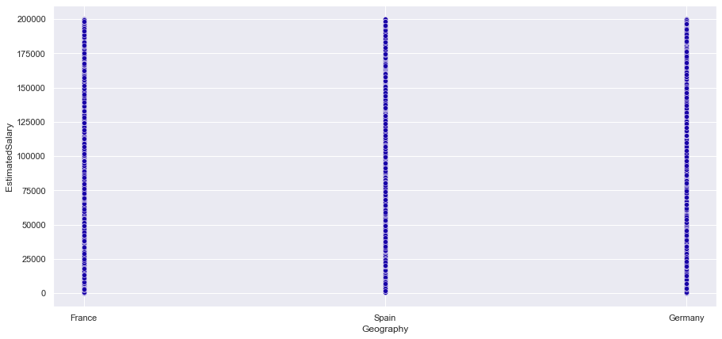

```python
# Display scatter plot for data['Geography'] and data['EstimatedSalary'] showed as hue variation
plt.figure(figsize=(15,7))
sns.scatterplot(x= data['Geography'],y=data['EstimatedSalary'])
```

**Insights**

- there shows similar distribution of Estimated salary in all the Geographies.

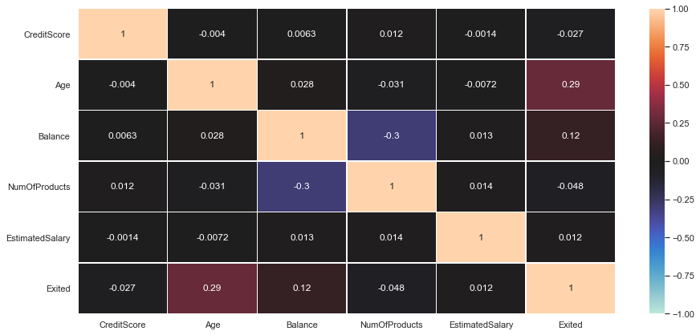

```python
#Display HeatMap for selected columns in the given pandas dataframe

all_col = [ 'CreditScore', 'Age','Balance', 'NumOfProducts', 'EstimatedSalary', 'Exited' ]

plt.figure(figsize=(15,7))

sns.heatmap(data[all_col].corr(),
            annot=True,
            linewidths=0.5,vmin=-1,vmax=1,
            center=0,
            cbar=True,)

plt.show()
```

**Insights**

- The corr numbers donot show any significant correletaion between any two columns.
- Even the exited column does not show decent corr between cols as data is unbalanced.
- Only exception is Number of Products and Balance have negative correlation. but the number is not huge. it shows moderate correlation between two columns.

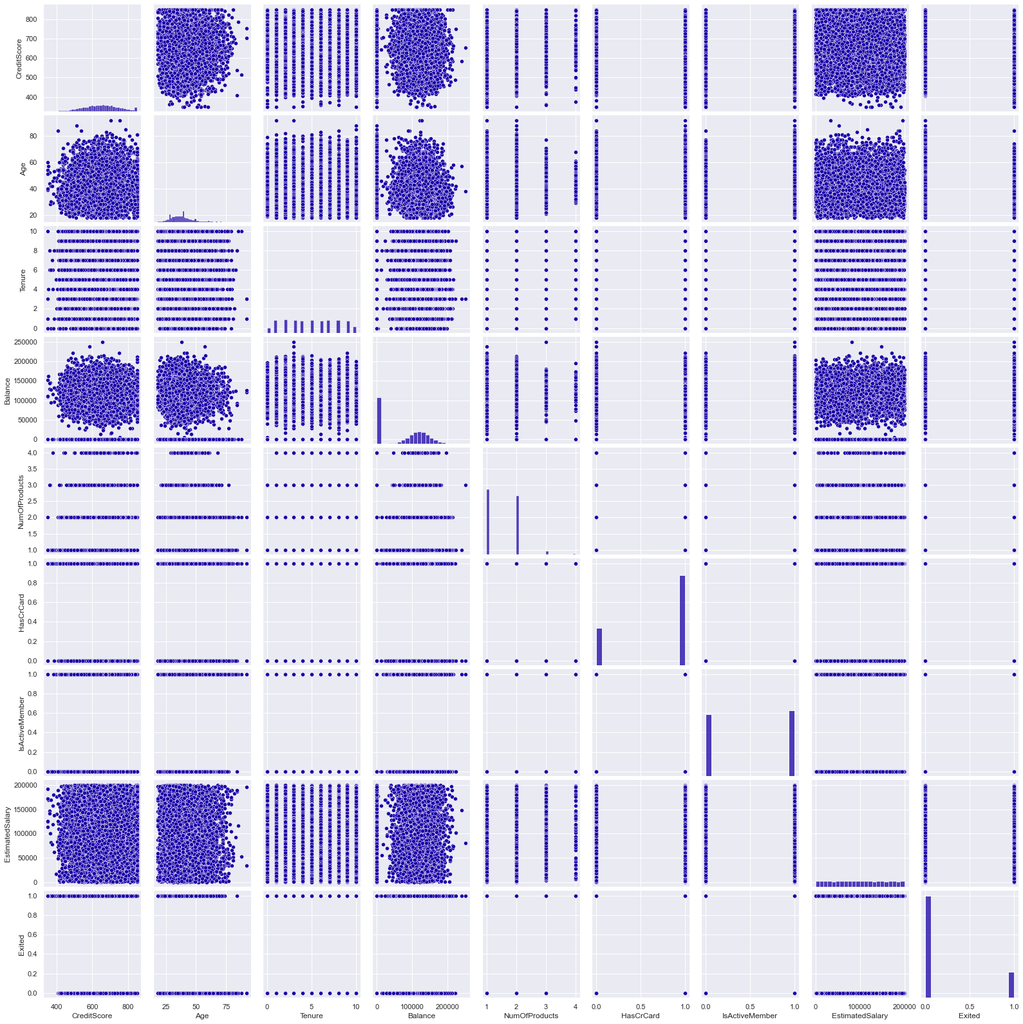

```python
sns.pairplot(data)
```

**Insights from pairplot**

- numeric column creditscore did not show any linear correlation with other cols like EstimatedSalary,Balance ,Age.
- balance has no linear correlation with age. data is speard all over as a cloud with out specific pattern.
- All age group customers are found with in all tenure periods.
- Product 4 is more popular among middle age group.

## Illustrate the insights based on EDA

- All other time periods of tenure have similar churn numbers.
- Customers with one products showed major exit rate. There are very less customers with 3 or 4 products.
- Estimated Salary shows no influence on churn rate. all salary range show similar churn numbers.
- There is similar distribution of credit score in all the given geographicla areas.
- There are few customers with less credit score in all tenure time periods.
- Few customers with 0 tenure have high credit score. Bank might have given this with previous customer history.
- There is no proper pattern between Balance and Credit Score.
- what looks abnormal is few customers with 0 balance are given high credit score.
- there shows similar distribution of Estimated salary in all the Geographies.
- Customers with mid credit score(600- 700) range exited more.
- Also customer with high score also exited. This is shown by some unusual raise at the end.
  - Customers with high score might have got some better offers from other providers.
  - Customers with mid credit score might be not satisfied with the current bank services.

**Looks like Account Balance,Number of Products,Age, CreditScore numbers show some affect on churn rate**

## Data Pre-processing

```python
data.columns
```

```
Index(['CreditScore', 'Geography', 'Gender', 'Age', 'Tenure', 'Balance',
       'NumOfProducts', 'HasCrCard', 'IsActiveMember', 'EstimatedSalary',
       'Exited'],
      dtype='object')
```

### Outlier Detection

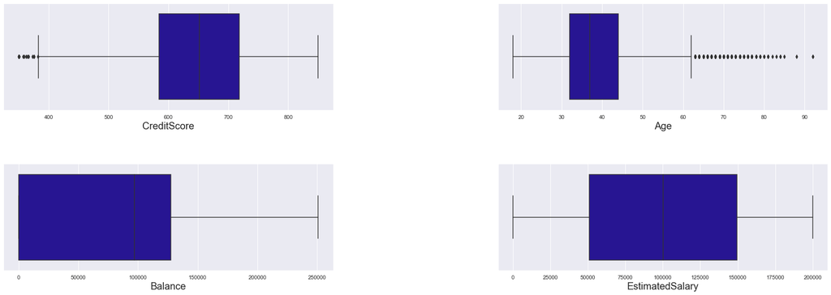

```python
fig, ax_list = plt.subplots(2, 2, figsize=(30,10))  # create 3*2 subplots
fig.subplots_adjust( wspace=0.5, hspace=0.5)    # to increase distance between subplots

cols = ['CreditScore', 'Age',  'Balance', 'EstimatedSalary']
row,col = (0,0)
for feature in cols:
    row_count = row
    col_count = col
    g = sns.boxplot(x= data[feature], ax=ax_list[row_count,col_count]) # boxplot  for given feature
    g.set_xlabel(feature, fontsize = 20)    # set label
    if(col==1):     # logic to set subplot ax for boxplot
        row = row+1
        col = 0
    else:
        col= col+1
plt.show()
```

**Insights**

But here in the problem, I am not handling outliers replacement for two reasons:

- Outliers don't appear to be very abnormal or as error
- Want model learn the special cases and work for outliers also.

```python
data.info()
```

```
<class 'pandas.core.frame.DataFrame'>
RangeIndex: 10000 entries, 0 to 9999
Data columns (total 11 columns):
 #   Column           Non-Null Count  Dtype
---  ------           --------------  -----
 0   CreditScore      10000 non-null  int64
 1   Geography        10000 non-null  object
 2   Gender           10000 non-null  object
 3   Age              10000 non-null  int64
 4   Tenure           10000 non-null  int64
 5   Balance          10000 non-null  float64
 6   NumOfProducts    10000 non-null  int64
 7   HasCrCard        10000 non-null  int64
 8   IsActiveMember   10000 non-null  int64
 9   EstimatedSalary  10000 non-null  float64
 10  Exited           10000 non-null  int64
dtypes: float64(2), int64(7), object(2)
memory usage: 859.5+ KB
```

### Split data into dependent and Independent variable

```python
X = data.drop(['Exited'],axis=1) # independent cols
y = data.iloc[:,-1] # dependent column
```

### One hot Encoding

```python
# get one hot encoding for categorical columns
X = pd.get_dummies(X, columns=['Geography'])
X = pd.get_dummies(X, columns=['Gender'])
```

```python
X.info()
```

```
<class 'pandas.core.frame.DataFrame'>
RangeIndex: 10000 entries, 0 to 9999
Data columns (total 13 columns):
 #   Column             Non-Null Count  Dtype
---  ------             --------------  -----
 0   CreditScore        10000 non-null  int64
 1   Age                10000 non-null  int64
 2   Tenure             10000 non-null  int64
 3   Balance            10000 non-null  float64
 4   NumOfProducts      10000 non-null  int64
 5   HasCrCard          10000 non-null  int64
 6   IsActiveMember     10000 non-null  int64
 7   EstimatedSalary    10000 non-null  float64
 8   Geography_France   10000 non-null  uint8
 9   Geography_Germany  10000 non-null  uint8
 10  Geography_Spain    10000 non-null  uint8
 11  Gender_Female      10000 non-null  uint8
 12  Gender_Male        10000 non-null  uint8
dtypes: float64(2), int64(6), uint8(5)
memory usage: 674.0 KB
```

```python
#with  One hot encoding of binary categorical col, one category col can be removed as this category is implied from other col.
X = X.drop(['Gender_Male'],axis = 1)
```

```python
X.head()
```

|  | CreditScore | Age | Tenure | Balance | NumOfProducts | HasCrCard | IsActiveMember | EstimatedSalary | Geography_France | Geography_Germany | Geography_Spain | Gender_Female |
| --- | --- | --- | --- | --- | --- | --- | --- | --- | --- | --- | --- | --- |
| 0 | 619 | 42 | 2 | 0.00 | 1 | 1 | 1 | 101348.88 | 1 | 0 | 0 | 1 |
| 1 | 608 | 41 | 1 | 83807.86 | 1 | 0 | 1 | 112542.58 | 0 | 0 | 1 | 1 |
| 2 | 502 | 42 | 8 | 159660.80 | 3 | 1 | 0 | 113931.57 | 1 | 0 | 0 | 1 |
| 3 | 699 | 39 | 1 | 0.00 | 2 | 0 | 0 | 93826.63 | 1 | 0 | 0 | 1 |
| 4 | 850 | 43 | 2 | 125510.82 | 1 | 1 | 1 | 79084.10 | 0 | 0 | 1 | 1 |

### Split data into train , validation and test set

```python
# Split data into training set and test set
X_train, X_test, y_train, y_test = train_test_split(X, y, test_size = 0.2, random_state = 7)

#Split the train set into training set and validation set
X_train, X_val, y_train, y_val = train_test_split(X_train, y_train, test_size=0.20, random_state=1)
```

```python
# Train, validation,test data sets shape

print('X_train.shape ',X_train.shape)
print('y_train.shape ',y_train.shape)
print('X_val.shape ',X_val.shape)
print('y_val.shape ',y_val.shape)
print('X_test.shape ',X_test.shape)
print('y_test.shape ',y_test.shape)
```

```
X_train.shape  (6400, 12)
y_train.shape  (6400,)
X_val.shape  (1600, 12)
y_val.shape  (1600,)
X_test.shape  (2000, 12)
y_test.shape  (2000,)
```

```python
X_train.columns
```

```
Index(['CreditScore', 'Age', 'Tenure', 'Balance', 'NumOfProducts', 'HasCrCard',
       'IsActiveMember', 'EstimatedSalary', 'Geography_France',
       'Geography_Germany', 'Geography_Spain', 'Gender_Female'],
      dtype='object')
```

### Data Scaling

```python
# perform standard scaling on all numeric cols
scaler = StandardScaler().fit(X_train)

# perfom on training and test data saperately to prevent data leakage.
X_train_scale = scaler.transform(X_train)
X_val_scale = scaler.transform(X_val)
X_test_scale = scaler.transform(X_test)
```

```python
X_train = pd.DataFrame(X_train_scale, columns = X_train.columns )
X_val = pd.DataFrame(X_val_scale, columns = X_val.columns )
X_test = pd.DataFrame(X_test_scale, columns = X_test.columns )
```

```python
# check the data by displaying the X_train
X_train
```

|  | CreditScore | Age | Tenure | Balance | NumOfProducts | HasCrCard | IsActiveMember | EstimatedSalary | Geography_France | Geography_Germany | Geography_Spain | Gender_Female |
| --- | --- | --- | --- | --- | --- | --- | --- | --- | --- | --- | --- | --- |
| 0 | -1.079510 | 1.240988 | -1.041208 | -1.240796 | -0.908177 | 0.642983 | -1.037581 | 0.639621 | 0.990050 | -0.575666 | -0.571336 | 1.082111 |
| 1 | -0.893099 | -0.747860 | -0.004535 | 0.713162 | -0.908177 | 0.642983 | 0.963780 | -1.395882 | -1.010051 | -0.575666 | 1.750283 | -0.924120 |
| 2 | 0.121806 | 3.324542 | 0.341022 | -1.240796 | 0.811957 | 0.642983 | -1.037581 | 0.400228 | 0.990050 | -0.575666 | -0.571336 | -0.924120 |
| 3 | 1.685588 | -0.463739 | -1.732322 | -1.240796 | 0.811957 | 0.642983 | -1.037581 | -0.999977 | 0.990050 | -0.575666 | -0.571336 | -0.924120 |
| 4 | -1.970141 | -0.369032 | 1.032137 | 0.412030 | 0.811957 | 0.642983 | 0.963780 | 1.545187 | -1.010051 | 1.737117 | -0.571336 | 1.082111 |
| ... | ... | ... | ... | ... | ... | ... | ... | ... | ... | ... | ... | ... |
| 6395 | -0.116386 | -0.463739 | 0.686579 | 1.171291 | 0.811957 | -1.555250 | -1.037581 | 0.975965 | -1.010051 | -0.575666 | 1.750283 | -0.924120 |
| 6396 | -0.385646 | 0.578038 | 1.377694 | 1.055870 | 0.811957 | 0.642983 | -1.037581 | -1.146580 | -1.010051 | 1.737117 | -0.571336 | 1.082111 |
| 6397 | 1.002081 | 0.104503 | -0.695650 | -1.240796 | -0.908177 | -1.555250 | -1.037581 | -0.744910 | 0.990050 | -0.575666 | -0.571336 | 1.082111 |
| 6398 | 1.354191 | -0.937274 | 0.341022 | 0.347956 | -0.908177 | -1.555250 | -1.037581 | 0.202055 | -1.010051 | -0.575666 | 1.750283 | 1.082111 |
| 6399 | 0.898519 | -0.084911 | 0.341022 | 1.112457 | 0.811957 | 0.642983 | -1.037581 | 1.704973 | -1.010051 | -0.575666 | 1.750283 | -0.924120 |

6400 rows × 12 columns

## Model evaluation criterion

### Model Objective

- To determine whether the customer will leave the bank or not in the next 6 months.

### Model can make wrong predictions as:

- Predicting a customer exit the bank but he did not exit.
- Predicting a customer would not exit the bank but he exited.

### Which case is more important?

- Predicting a customer would not exit the bank but he exited. This will be a loss to the business and againsts the objective.

### How to reduce this loss i.e need to reduce False Negative?

- Company would like to capture all most all the customers hwo are about to leave.
- Company would want `Recall` to be maximized, greater the Recall higher the chances of minimizing false Negative. Hence, The main focues is to minimize the false Negative or identify the True Positive(i.e. Class 1) so that the Company can identify the maximum exited customers.

```python
def make_confusion_matrix(cf,
                          group_names=None,
                          categories='auto',
                          count=True,
                          percent=True,
                          cbar=True,
                          xyticks=True,
                          xyplotlabels=True,
                          sum_stats=True,
                          figsize=None,
                          cmap='Blues',
                          title=None):
    '''
    This function will make a pretty plot of an sklearn Confusion Matrix cm using a Seaborn heatmap visualization.
    Arguments
    '''
    ( accuracy, precision, recall, f1_score ) = (0,0,0,0)

    # CODE TO GENERATE TEXT INSIDE EACH SQUARE
    blanks = ['' for i in range(cf.size)]

    if group_names and len(group_names)==cf.size:
        group_labels = ["{}\n".format(value) for value in group_names]
    else:
        group_labels = blanks

    if count:
        group_counts = ["{0:0.0f}\n".format(value) for value in cf.flatten()]
    else:
        group_counts = blanks

    if percent:
        group_percentages = ["{0:.2%}".format(value) for value in cf.flatten()/np.sum(cf)]
    else:
        group_percentages = blanks

    box_labels = [f"{v1}{v2}{v3}".strip() for v1, v2, v3 in zip(group_labels,group_counts,group_percentages)]
    box_labels = np.asarray(box_labels).reshape(cf.shape[0],cf.shape[1])


    # CODE TO GENERATE SUMMARY STATISTICS & TEXT FOR SUMMARY STATS
    if sum_stats:
        #Accuracy is sum of diagonal divided by total observations
        accuracy  = np.trace(cf) / float(np.sum(cf))

        #if it is a binary confusion matrix, show some more stats
        if len(cf)==2:
            #Metrics for Binary Confusion Matrices
            precision = cf[1,1] / sum(cf[:,1])
            recall    = cf[1,1] / sum(cf[1,:])
            f1_score  = 2*precision*recall / (precision + recall)
            stats_text = "\n\nAccuracy={:0.3f}\nPrecision={:0.3f}\nRecall={:0.3f}\nF1 Score={:0.3f}".format(
                accuracy,precision,recall,f1_score)
        else:
            stats_text = "\n\nAccuracy={:0.3f}".format(accuracy)
    else:
        stats_text = ""


    # SET FIGURE PARAMETERS ACCORDING TO OTHER ARGUMENTS
    if figsize==None:
        #Get default figure size if not set
        figsize = plt.rcParams.get('figure.figsize')

    if xyticks==False:
        #Do not show categories if xyticks is False
        categories=False


    # MAKE THE HEATMAP VISUALIZATION
    plt.figure(figsize=figsize)
    sns.heatmap(cf,annot=box_labels,fmt="",cmap=cmap,cbar=cbar,xticklabels=categories,yticklabels=categories)

    if xyplotlabels:
        plt.ylabel('True label')
        plt.xlabel('Predicted label' + stats_text)
    else:
        plt.xlabel(stats_text)

    if title:
        plt.title(title)
    if sum_stats:
        if len(cf)==2:
            return ( accuracy, precision, recall, f1_score )
```

## Model Building

### Model - 1

- Fully connected network with ReLu activation.
- The NN takes a vector of length 12 as input.
- For each customer inf, the final layer will output a probability distribution (sigmoid activation function) to predict if particular customer will exit or not exit in next 6 months.

```python
#initialize the model
model1 = Sequential()
```

**Model Definition - Adding layers [layers and activations]**

- Input layer with 12 inputs
- First hidden layer has 16 neutrons.
- Second hidden layer has 32 neutrons.
- The given problem is Binary classification problem so sigmoid function is used in the output layer.

```python
model1.add(Dense(units=12, input_dim = X_train.shape[1]))  # Input layer with 12 columns as input
model1.add(Dense(units=16, activation='relu'))   # Add First hidden layer
model1.add(Dense(units=32, activation='relu'))    # Add Second hidden layer

# we have an output of 1 node, which is the the desired dimensions of our output (whether customer exit or not)
# We use the sigmoid because we have binary classification and looking for probability outputs.
model1.add(Dense(1,activation='sigmoid'))   # Add output layer
```

**Model Compilation**

```python
optimizer = tf.keras.optimizers.Adam(0.01)  # optimizer function Adam is defined with learning rate = 0.01
model1.compile(optimizer=optimizer,loss='binary_crossentropy',metrics=[tf.keras.metrics.Recall()]) # metrics recall is used
```

```python
model1.summary()
```

```
Model: "sequential"
_________________________________________________________________
Layer (type)                 Output Shape              Param #
=================================================================
dense (Dense)                (None, 12)                156
_________________________________________________________________
dense_1 (Dense)              (None, 16)                208
_________________________________________________________________
dense_2 (Dense)              (None, 32)                544
_________________________________________________________________
dense_3 (Dense)              (None, 1)                 33
=================================================================
Total params: 941
Trainable params: 941
Non-trainable params: 0
_________________________________________________________________
```

**Training [Forward pass and Backpropagation]**

```python
# fitting the model
# epochs is Number of epochs to train the model.
# Model1 is made simple with no complexity added to it.  so starting with 10 epochs.
# batch_size is set to 150.
# training data set is split by 0.2 to use as validation dataset.

history1 = model1.fit(X_train,y_train,batch_size=150,epochs=10,validation_data=(X_val,y_val))
```

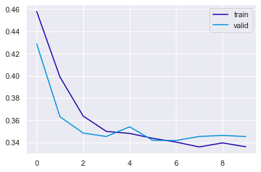

```python
# Capturing learning history per epoch
hist  = pd.DataFrame(history1.history)
hist['epoch'] = history1.epoch

# Plotting accuracy at different epochs
plt.plot(hist['loss'])
plt.plot(hist['val_loss'])
plt.legend(("train" , "valid") , loc = 0)
```

**Insights**

Training curve is decresing and Validation curve cross train curve and started incresing. This is over fit model behaviour. so over fit can be tried reducing by adding Dropout after layers.

Both validation and training metrics are yet to converge . we can try by increasing number of epochs.

The variance, overfit can be handled by decreasing the learning rate to some extent.

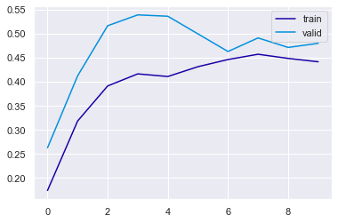

```python
# Capturing recall per epoch
hist  = pd.DataFrame(history1.history)
hist['epoch'] = history1.epoch

# Plotting recall at different epochs
plt.plot(hist['recall'])
plt.plot(hist['val_recall'])
plt.legend(("train" , "valid") , loc =0)
```

**Insights**

The validation curve is not smooth,This shows there is some variance. we can try by decreasing the learning rate.

## Model Performance Improvement

**Which metric is important**

**Model Objective**

- To determine whether the customer will leave the bank or not in the next 6 months.

**Model can make wrong predictions as:**

- Predicting a customer exit the bank but he did not exit.[False Positive]
- Predicting a customer would not exit the bank but he exited.[False Negative]

**Which Error is more costly to Business ?**

- Predicting a customer would not exit the bank but he exited. This will be a greater loss to the business and is against the objective.
- Predicting a customer would exit the bank but he did not exit.This would waste some resources but will not have any loss for their business.

**Which metric is right for model performance evaluation and why?**

- Company would like to capture most or all of the customers who would exit.
- Recall metric defines how many true positives are captured among actual total positives. i.e In this case,Recall would define us **"Among all the exited customers, how many customers are correctly predicted as exited."**
- Company would want `Recall` to be maximized, greater the Recall higher the chances of minimizing false Negative. Hence, The main focus is to minimize the false Negative or maximize the True Positive(i.e. Class 1) so that the Company can identify the maximum exited customers.

**so RECALL is important for this problem.**

### Model-1 Performance Evaluation

**ROC-AUC Curve**

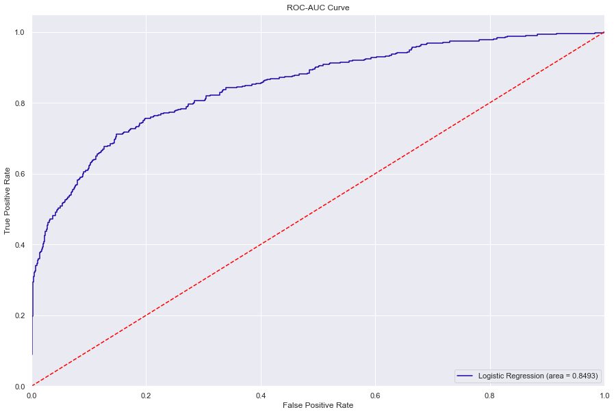

```python
logit_roc_auc1 = roc_auc_score(y_test, model1.predict(X_test)) # calculate area under the curve
fpr1, tpr1, thresholds1 = roc_curve(y_test, model1.predict(X_test))

#Generate ROC -AUC graph
plt.figure(figsize=(15,10))
plt.plot(fpr1, tpr1, label='Logistic Regression (area = %0.4f)' % logit_roc_auc1)
plt.plot([0, 1], [0, 1],'r--')
plt.xlim([0.0, 1.0])
plt.ylim([0.0, 1.05])
plt.xlabel('False Positive Rate')
plt.ylabel('True Positive Rate')
plt.title('ROC-AUC Curve')
plt.legend(loc="lower right")
plt.show()
```

**Insights**

- AOU(0.8493) is not very less. it is decent.
- Area under the curve can be improved by adjusting below hyperparameters in NN.
- ROC curve for unbalanced data can be not accurate in results. we can try precision-recall curve.

i) Adding or decreasing new layers.  
ii) Increasing or decreasing the learning rate.  
iii) Increasing epochs  
iv) Adding callbacks

From the learning rate and loss graphs, the the model is overfit. so we can improve performance  
i) by decreasing learning rate  
ii) by increasing epochs  
iii) by adding dropout after layers

```python
score_weighted1 = model1.evaluate(X_test, y_test)
```

**Optimal threshold**

Trying to find optimal_proba_cutoff from the ROC-AUC curve:

- find the difference between true positive rate , false positive rate with tpr>fpr( in our problem we are more intrested in tpr i.e recall)
- Arrange the difference in descending order.
- Find the treshould where the difference is more.

```python
optimal_proba_cutoff1 = sorted(list(zip(np.subtract(tpr1,fpr1), thresholds1)), key=lambda i: i[0], reverse=True)[0][1]
```

```python
print('optimal_proba_cutoff of model_1 :',optimal_proba_cutoff1)
```

```
optimal_proba_cutoff of model_1 : 0.22533086
```

**Confusion Matrix**

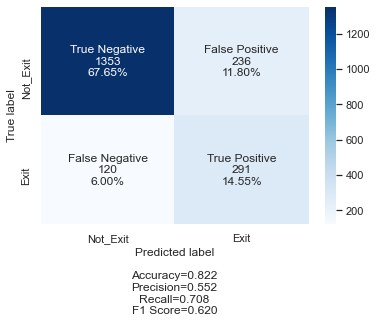

```python
# Convert prediction probabilites to predictions using optimal_proba_cutoff

## Confusion Matrix on unsee test set
import seaborn as sn
y_pred1 = model1.predict(X_test)
for i in range(len(y_test)):
    if y_pred1[i]>optimal_proba_cutoff1:
        y_pred1[i]=1
    else:
        y_pred1[i]=0




cm1 = confusion_matrix(y_test, y_pred1)
labels = ['True Negative','False Positive','False Negative','True Positive']
categories = [ 'Not_Exit','Exit']
( accuracy1, precision1, recall1, f1_score1 ) = make_confusion_matrix(cm1,
                      group_names=labels,
                      categories=categories,
                      cmap='Blues')
```

**Insights**

- Recall score is 0.708 which is descent score for this dataset But
- There are still 120 cases as False Negatives which is very costly to the business. This can be tried to reduce.

```python
# Add all metrics of model in one dataframe to facilitate comparition between models.

metrics_cols = ['model','epochs','learning_rate','recall','precision','accuracy','f1_score','ROC-AUC','Pred-Recall-AUC','prob_cut_off','model_desc']
model1_desc = '2 hidden layers,no  dropouts'
model_evaluation_metrics1 = pd.DataFrame(np.array([['model1',10, 0.01, recall1, precision1, accuracy1, f1_score1,logit_roc_auc1, 'NA', optimal_proba_cutoff1, model1_desc ]]), columns = metrics_cols)
model_evaluation_metrics1
```

|  | model | epochs | learning_rate | recall | precision | accuracy | f1_score | ROC-AUC | Pred-Recall-AUC | prob_cut_off | model_desc |
| --- | --- | --- | --- | --- | --- | --- | --- | --- | --- | --- | --- |
| 0 | model1 | 10 | 0.01 | 0.708029197080292 | 0.5521821631878557 | 0.822 | 0.6204690831556503 | 0.8492601966990211 | NA | 0.22533086 | 2 hidden layers,no dropouts |